# Regresión Lineal

## Introducción

El [análisis de regresión lineal](https://docplayer.es/12926031-Capitulo-18-analisis-de-regresion-lineal-el-procedimiento-regresion-lineal.html) es una técnica estadística utilizada para estudiar la relación entre variables. Se adapta a una amplia variedad de situaciones. En la investigación social, el análisis de regresión se utiliza para predecir un amplio rango de fenómenos, desde medidas económicas hasta diferentes aspectos del comportamiento humano. En el contexto de la investigación de mercados puede utilizarse para determinar en cuál de diferentes medios de comunicación puede resultar más eficaz invertir; o para predecir el número de ventas de un determinado producto. En física se utiliza para caracterizar la relación entre variables o para calibrar medidas. Etc.

La siguiente gráfica es un ejemplo de regresión lineal con una variable dependiente y una variable independiente.

[figure not shown]

Tanto en el caso de dos variables (regresión *simple* ) como en el de más de dos variables (regresión *Múltiple* ), el análisis de regresión lineal puede utilizarse para explorar y cuantificar la relación entre una variable llamada dependiente o criterio ${\displaystyle Y}$ y una o más variables llamadas independientes o predictoras ${\displaystyle X_{1}, X_{2},...X_{k}}$, así como para desarrollar una ecuación lineal con fines predictivos. Además, el análisis de regresión lleva asociados una serie de procedimientos de diagnóstico (análisis de los residuos, puntos de influencia) que informan sobre la estabilidad e idoneidad del análisis y que proporcionan pistas sobre cómo perfeccionarlo.

## Historia

La primera forma de [regresión lineal](https://es.wikipedia.org/wiki/Regresi%C3%B3n_lineal) documentada fue el método de los [mínimos cuadrados](https://es.wikipedia.org/wiki/M%C3%ADnimos_cuadrados) que fue publicada por Legendre en 1805, Gauss publicó un trabajo en donde desarrollaba de manera más profunda el método de los mínimos cuadrados, y en dónde se incluía una versión del teorema de Gauss-Márkov

[figure not shown]

.

El término regresión se utilizó por primera vez en el estudio de variables antropométricas: al comparar la estatura de padres e hijos, donde resultó que los hijos cuyos padres tenían una estatura muy superior al valor medio, tendían a igualarse a este, mientras que aquellos cuyos padres eran muy bajos tendían a reducir su diferencia respecto a la estatura media; es decir, "regresaban" al promedio. La constatación empírica de esta propiedad se vio reforzada más tarde con la justificación teórica de ese fenómeno.

El término lineal se emplea para distinguirlo del resto de técnicas de regresión, que emplean modelos basados en cualquier clase de función matemática. Los modelos lineales son una explicación simplificada de la realidad, mucho más ágiles y con un soporte teórico mucho más extenso por parte de la matemática y la estadística.

Pero bien, como se ha dicho, se puede usar el término lineal para distinguir modelos basados en cualquier clase de aplicación.

## El Modelo de Regresión Lineal

El [modelo](https://es.wikipedia.org/wiki/Regresi%C3%B3n_lineal) lineal relaciona la variable dependiente ${\displaystyle Y}$ con ${\displaystyle m}$ variables regresoras ${\displaystyle X_{j}}$ con ${\displaystyle j=1,2,\dots ,m}$ o cualquier transformación de éstas que generen un hiperplano de parámetros ${\displaystyle \beta _{i}}$ desconocidos:

\begin{aligned}Y&=\beta _{0}+\beta _{1}X_{1}+\cdots +\beta _{m}X_{m}+\varepsilon \\&=\beta _{0}+\sum _{j=1}^{m}\beta _{j}X_{j}+\varepsilon \end{aligned}

donde ${\displaystyle \varepsilon }$ es una variable aleatoria que recoge todos aquellos factores de la realidad no controlables u observables y que por tanto se asocian con el azar, y es la que confiere al modelo su carácter estocástico. En el caso más sencillo, con una sola variable explícita, el hiperplano es una recta:

$${\displaystyle Y=\beta _{0}+\beta _{1}X_{1}+\varepsilon}$$

El problema de la regresión consiste en elegir unos valores determinados para los parámetros desconocidos ${\displaystyle \beta _{j}}$, de modo que la ecuación quede completamente especificada. Para ello se necesita un conjunto de observaciones o una muestra proveniente de este modelo. En una observación ${\displaystyle i}-esima$ ${\displaystyle (i=1,2,\dots ,n)}$ cualquiera, se registra el comportamiento simultáneo de la variable dependiente y las variables explícitas (las perturbaciones aleatorias se suponen no observables).

$${\displaystyle y_{i}=\beta _{0}+\sum _{j=1}^{m}\beta _{j}x_{ij}+\varepsilon _{i}}$$

Los valores escogidos como estimadores de los parámetros ${\displaystyle {\hat {\beta }}_{j}}$, son los coeficientes de regresión sin que se pueda garantizar que coincidan con parámetros reales del proceso generador. Por tanto, en

$${\displaystyle Y_{i}=\beta _{0}+\sum _{j=1}^{m}{\hat {\beta }}_{j}X_{ij}+{\hat {\varepsilon }}_{i}}$$

Los valores ${\displaystyle {\hat {\varepsilon }}_{i}}$ son por su parte estimaciones o errores de la perturbación aleatoria.

de [forma matricial](https://www.cienciadedatos.net/documentos/py10-regresion-lineal-python.html):

Matricial ampliada:

$${\displaystyle Y={\begin{pmatrix}y_{1}\\y_{2}\\\vdots \\y_{n}\end{pmatrix}}\qquad \qquad X={\begin{pmatrix}1&x_{11}&x_{12}&\cdots &x_{1m}\\1&x_{21}&x_{22}&\cdots &x_{2m}\\\vdots &\vdots &\vdots &\ddots &\vdots \\1&x_{n1}&x_{n2}&\cdots &x_{nm}\end{pmatrix}}} \qquad \qquad {\displaystyle \beta ={\begin{pmatrix}\beta _{0}\\\beta _{1}\\\vdots \\\beta _{m}\end{pmatrix}}\qquad \qquad \varepsilon ={\begin{pmatrix}\varepsilon _{1}\\\varepsilon _{2}\\\vdots \\\varepsilon _{n}\end{pmatrix}}}$$

## Ejemplo de Regresión Lineal

Para trabajar el ejemplo se hace uso de la base de datos disponible en una práctica de la [Universidad de Granada](http://wpd.ugr.es/~bioestad/guia-r-commander/practica-3/) (España)

La base de datos *empleados* contiene información de la edad, altura, peso y sexo de 99 empleados de una empresa.

Para desarrollar el ejemplo se sigue [Aprende Machine Learning](https://www.aprendemachinelearning.com/regresion-lineal-en-espanol-con-python/)

### Librerias necesarias

```python
import numpy as np
import pandas as pd
import seaborn as sb
import matplotlib.pyplot as plt
%matplotlib inline
from mpl_toolkits.mplot3d import Axes3D
from matplotlib import cm
plt.rcParams['figure.figsize'] = (16, 9)
plt.style.use('ggplot')
from sklearn import linear_model
from sklearn.metrics import mean_squared_error, r2_score
```

### Carga de datos

```python
#cargamos los datos de entrada
data = pd.read_csv("empleados.csv")
#veamos cuantas dimensiones y registros contiene
data.shape
```

```
(99, 4)
```

### Primeros valores base de datos

```python
#son 99 registros con 4 columnas. Veamos los primeros registros
data.head()
```

|  | Edad | Altura | Peso | Sexo |
| --- | --- | --- | --- | --- |
| 0 | 20 | 178 | 82 | Hombre |
| 1 | 18 | 168 | 87 | Hombre |
| 2 | 19 | 194 | 94 | Hombre |
| 3 | 19 | 159 | 62 | Mujer |
| 4 | 21 | 177 | 78 | Hombre |

#### Estadísticas básicas

```python
# Algunas estadísticas de los datos
data.describe()
```

|  | Edad | Altura | Peso |
| --- | --- | --- | --- |
| count | 99.000000 | 99.000000 | 99.000000 |
| mean | 20.515152 | 177.000000 | 74.757576 |
| std | 4.163406 | 8.213975 | 13.115726 |
| min | 18.000000 | 159.000000 | 51.000000 |
| 25% | 18.000000 | 171.000000 | 67.000000 |
| 50% | 19.000000 | 178.000000 | 72.000000 |
| 75% | 22.000000 | 182.000000 | 82.000000 |
| max | 51.000000 | 200.000000 | 120.000000 |

### Visualización general de datos (Scatter plot)

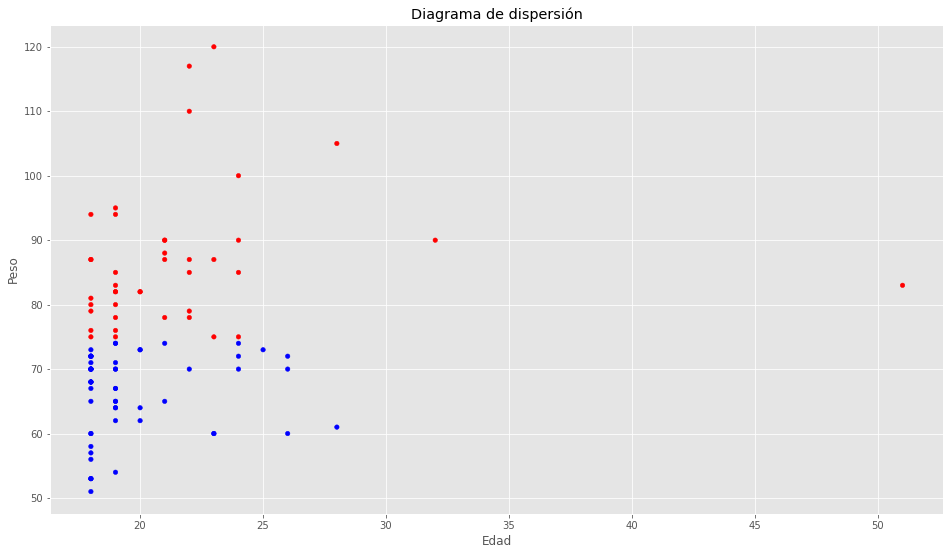

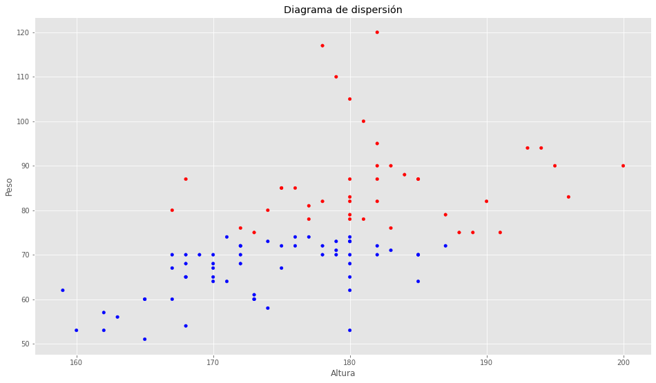

```python
#Visualizar los datos de entrada
colores=['red','blue']
tamanios=[20,40]

f1 = data['Edad'].values
f2 = data['Altura'].values
f3 = data['Peso'].values


# Vamos a pintar en 2 colores los puntos por debajo de la media de LA TASA DE NATALIDAD
asignar=[]
for index, row in data.iterrows():
    if(row['Peso']>74.7):
        asignar.append(colores[0])
    else:
        asignar.append(colores[1])

plt.scatter(f1, f3, c=asignar, s=tamanios[0])
plt.xlabel('Edad')
plt.ylabel('Peso')
plt.title('Diagrama de dispersión')
plt.show()

plt.scatter(f2, f3, c=asignar, s=tamanios[0])
plt.xlabel('Altura')
plt.ylabel('Peso')
plt.title('Diagrama de dispersión')
plt.show()
```

### SKLEARN

```python
dXt1 = pd.DataFrame()
dXt2 = pd.DataFrame()
dYt = pd.DataFrame()

dXt1['Altura']=data['Altura']
dXt2['Edad']=data['Edad']

#dXts['Altura']=data['Altura']

dYt['Peso']=data['Peso']

#print(dX)
#print(dY)

X_t1=np.array(dXt1)
X_t2=np.array(dXt2)
Y_t=np.array(dYt)
print(X_t1.shape)
```

```
(99, 1)
```

### Regresión Lineal Simple

Peso en función de la Altura

```python
# Creamos el objeto de Regresión Linear
regr = linear_model.LinearRegression()

# Entrenamos nuestro modelo
regr.fit(X_t1, Y_t)

Y_pred = regr.predict(X_t1)
#Y1_pred=5.573*X_ts+24.17

# Veamos los coeficienetes obtenidos,
print('Coefficients: \n', regr.coef_)
# Este es el valor donde corta el eje Y (en X=0)
print('Independent term: \n', regr.intercept_)
# Error Cuadrado Medio
print("Mean squared error: %.2f" % mean_squared_error(Y_t, Y_pred))
# Puntaje de Varianza. El mejor puntaje es un 1.0
print('Variance score: %.2f' % r2_score(Y_t, Y_pred))
```

```
Coefficients:
 [[0.86857229]]
Independent term:
 [-78.97972007]
Mean squared error: 119.90
Variance score: 0.30
```

### Visualización de la Recta

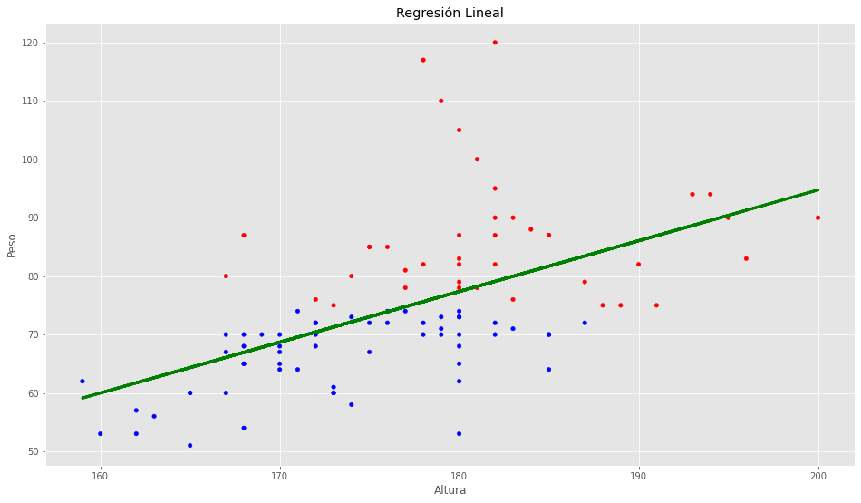

```python
plt.scatter(X_t1[:,0], Y_t,  c=asignar, s=tamanios[0])
plt.plot(X_t1[:,0], Y_pred, color='green', linewidth=3)

plt.xlabel('Altura')
plt.ylabel('Peso')
plt.title('Regresión Lineal')

plt.show()
```

### Predicción utilizando el modelo

```python
#Vamos a comprobar:
# Quiero predecir cuántos "Shares" voy a obtener por un artículo con 2.000 palabras,
# según nuestro modelo, hacemos:
y_180 = regr.predict([[180]])
print(int(y_180))
```

```
77
```

### Regresión Lineal Múltiple (Dos variables)

```python
dXt2 = pd.DataFrame()


dXt2['Altura']=data['Altura']
dXt2['Edad']=data['Edad']
X_t2=np.array(dXt2)

print(X_t2.shape)

# Creamos un nuevo objeto de Regresión Lineal
regr2 = linear_model.LinearRegression()

# Entrenamos el modelo, esta vez, con 2 dimensiones
# obtendremos 2 coeficientes, para graficar un plano
regr2.fit(X_t2, Y_t)

# Hacemos la predicción con la que tendremos puntos sobre el plano hallado
Y_predm = regr2.predict(X_t2)

# Los coeficientes
print('Independent term: \n', regr2.intercept_)
print('Coefficients: \n', regr2.coef_)
# Error cuadrático medio
print("Mean squared error: %.2f" % mean_squared_error(Y_t, Y_predm))
# Evaluamos el puntaje de varianza (siendo 1.0 el mejor posible)
print('Variance score: %.2f' % r2_score(Y_t, Y_predm))
```

```
(99, 2)
Independent term:
 [-86.82163517]
Coefficients:
 [[0.83765269 0.64901709]]
Mean squared error: 112.73
Variance score: 0.34
```

### Visualización del Plano

```
[[150.  162.5 175.  187.5 200. ]
 [150.  162.5 175.  187.5 200. ]
 [150.  162.5 175.  187.5 200. ]
 [150.  162.5 175.  187.5 200. ]
 [150.  162.5 175.  187.5 200. ]]
[[25.   25.   25.   25.   25.  ]
 [36.25 36.25 36.25 36.25 36.25]
 [47.5  47.5  47.5  47.5  47.5 ]
 [58.75 58.75 58.75 58.75 58.75]
 [70.   70.   70.   70.   70.  ]]
```

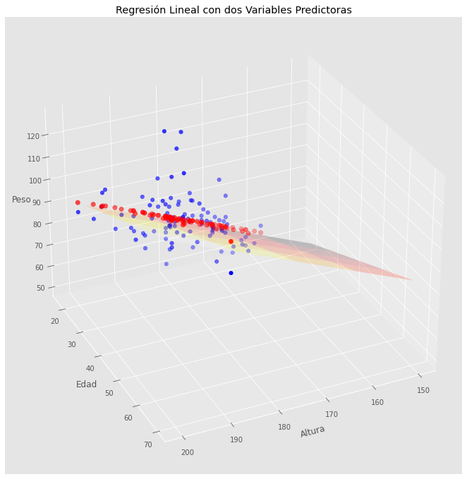

```python
fig = plt.figure()
ax = Axes3D(fig)

# Creamos una malla, sobre la cual graficaremos el plano
xx, yy = np.meshgrid(np.linspace(150, 200, num=5), np.linspace(25, 70, num=5))

print(xx)
print(yy)

# calculamos los valores del plano para los puntos x e y


nuevoX = (regr2.coef_[0,0] * xx)
nuevoY = (regr2.coef_[0,1] * yy)


# calculamos los correspondientes valores para z. Debemos sumar el punto de intercepción
z = (nuevoX + nuevoY + regr2.intercept_)

# Graficamos el plano
ax.plot_surface(xx, yy, z, alpha=0.2, cmap='hot')

# Graficamos en azul los puntos en 3D
ax.scatter(X_t2[:, 0], X_t2[:, 1], Y_t, c='blue',s=30)

# Graficamos en rojo, los puntos que
ax.scatter(X_t2[:, 0], X_t2[:, 1], Y_predm, c='red',s=40)

# con esto situamos la "camara" con la que visualizamos
ax.view_init(elev=30., azim=65)

ax.set_xlabel('Altura')
ax.set_ylabel('Edad')
ax.set_zlabel('Peso')
ax.set_title('Regresión Lineal con dos Variables Predictoras')
```

## Conclusiones

Mi conclusión no es con respecto al tema, es con respecto a realizar esta tarea. Para mi fue empezar a dimensionar que hay todo un mundo por explorar en esta temática y es bastante interesante conocer y aprender a utilizar las herramientas disponibles

## Bibliografía

Análisis de datos con SPSS 13 Base. Capitulo 18 Análisis de Regresión Lineal. El procedimiento Regresión lineal pag 337 McGraw-Hill Interamericana de España

Práctica 3, Regresión y Correlación Estadística Universidad de Granada [Link](http://wpd.ugr.es/~bioestad/guia-r-commander/practica-3/)

Aprende Machine Learning, Regresión Lineal en español con Pyton [Link](https://www.aprendemachinelearning.com/regresion-lineal-en-espanol-con-python/)

Wikipedia, La enciclopedia libre - Regresión lineal [Link](https://es.wikipedia.org/wiki/Regresi%C3%B3n_lineal)

Regresión lineal con Python by Joaquín Amat Rodrigo, available under a Attribution 4.0 International (CC BY 4.0) [at](https://www.cienciadedatos.net/documentos/py10-regresion-lineal-python.html)